# Pseudobulk Cell Comparison

Sneha M. Chaturvedi

Last updated 2026-09-04

[output not shown]

## Goals

Compare pseudobulk aggregation stability across varying cell count thresholds to determine an optimal minimum-cell cutoff for downstream analysis.

For each threshold N (10–200 in steps of 10), 20 random subsets of N cells per sample are drawn and Pearson r is computed between the subsampled log1p-pseudobulk and the full-sample log1p-pseudobulk.

## Set Up

```r
knitr::opts_chunk$set(echo = TRUE)

Packages <- c(
  "tidyverse", "Seurat", "Signac", "glue", "readxl", "cowplot",
  "edgeR", "limma", "patchwork", "svglite", "Matrix", "ggpubr"
)
lapply(Packages, library, character.only = TRUE)

source("pseudobulk_functions.R")
root <- find_project_root()

set.seed(123)
```

```r
comparison_cache <- readRDS(file.path(root, "data/cache/pb_comparison_subset.rds"))
counts_sub    <- comparison_cache$counts_sub
sample_labels <- comparison_cache$sample_labels
```

## Parameters

```r
TARGET_CELLTYPE <- "EN-IT-Immature"
TARGET_SAMPLES  <- c("SSD10_tissue10", "SSD43_tissue43")
THRESHOLDS <- seq(10, 200, by = 10)
N_REPS <- 20
SCATTER_THRESHOLDS <- c(10, 30, 50, 100, 150, 200)
```

## Extract Cell Indices and Count Matrix

```r
cell_counts_per_sample <- sample_labels
```

## Build Full-Pseudobulk Reference

```r
full_pb_log <- lapply(TARGET_SAMPLES, function(s) {
  idx <- which(sample_labels == s)
  log1p(as.numeric(Matrix::rowSums(counts_sub[, idx, drop = FALSE])))
})
names(full_pb_log) <- TARGET_SAMPLES
```

## Simulation: Correlation vs. Threshold

For each sample × threshold × replicate, randomly draw N cells (without replacement), aggregate to pseudobulk, log1p-transform, and compute Pearson r against the full pseudobulk.

```r
sim_results <- purrr::map_dfr(TARGET_SAMPLES, function(s) {
  idx_s <- which(sample_labels == s)
  ref_log <- full_pb_log[[s]]

  purrr::map_dfr(THRESHOLDS, function(n) {
    if (n > length(idx_s)) {
      return(NULL)
    }

    purrr::map_dfr(seq_len(N_REPS), function(rep_i) {
      sampled <- sample(idx_s, size = n, replace = FALSE)
      sub_log <- log1p(as.numeric(Matrix::rowSums(counts_sub[, sampled, drop = FALSE])))
      r <- cor(ref_log, sub_log, method = "pearson")
      tibble(sample = s, threshold = n, replicate = rep_i, r = r)
    })
  })
})
```

## Plot 1: Correlation vs. Threshold

Median Pearson r ± IQR across 20 draws per threshold per sample.

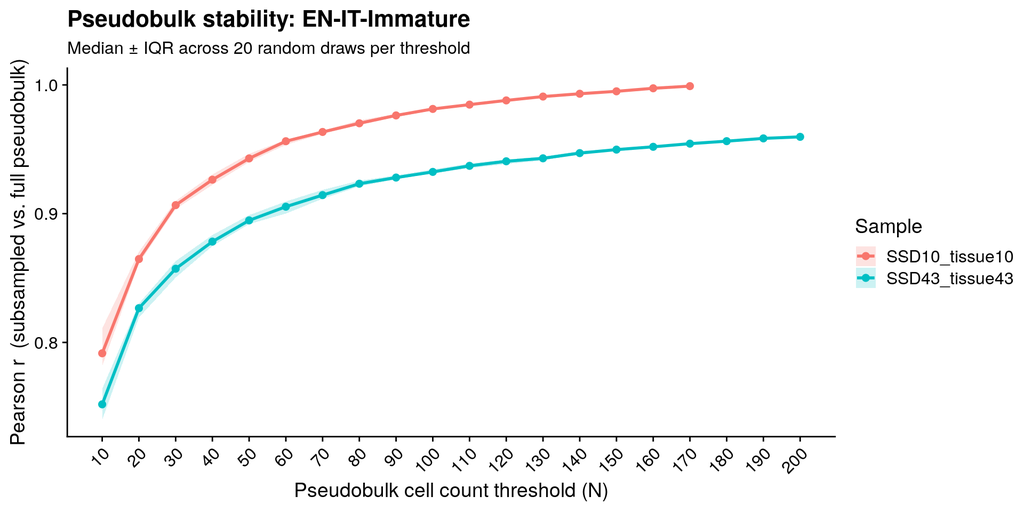

```r
summary_df <- sim_results |>
  group_by(sample, threshold) |>
  summarise(
    median_r = median(r),
    q25      = quantile(r, 0.25),
    q75      = quantile(r, 0.75),
    .groups  = "drop"
  )

p_line <- ggplot(summary_df, aes(
  x = threshold, y = median_r,
  color = sample, fill = sample
)) +
  geom_ribbon(aes(ymin = q25, ymax = q75), alpha = 0.2, color = NA) +
  geom_line(linewidth = 1) +
  geom_point(size = 2) +
  scale_x_continuous(breaks = THRESHOLDS) +
  scale_y_continuous(limits = c(NA, 1)) +
  labs(
    x        = "Pseudobulk cell count threshold (N)",
    y        = "Pearson r  (subsampled vs. full pseudobulk)",
    title    = glue("Pseudobulk stability: {TARGET_CELLTYPE}"),
    subtitle = "Median ± IQR across 20 random draws per threshold",
    color    = "Sample",
    fill     = "Sample"
  ) +
  theme_cowplot() +
  theme(axis.text.x = element_text(angle = 45, hjust = 1))

p_line
```

## Plot 2: Gene-Level Scatter at Selected Thresholds

One draw per threshold (using `set.seed` above). Points are genes with full pseudobulk > 0 (zeros excluded to avoid a dominant zero-zero cloud). Pearson r is annotated per panel.

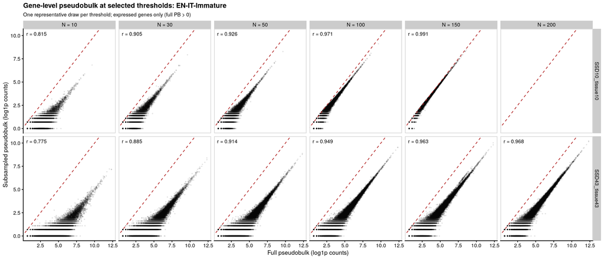

```r
scatter_data <- purrr::map_dfr(TARGET_SAMPLES, function(s) {
  idx_s <- which(sample_labels == s)
  ref_log <- full_pb_log[[s]]

  # Only correlate genes expressed in the full pseudobulk
  expressed <- ref_log > 0

  purrr::map_dfr(SCATTER_THRESHOLDS, function(n) {
    if (n > length(idx_s)) {
      return(NULL)
    }
    sampled <- sample(idx_s, size = n, replace = FALSE)
    sub_log <- log1p(as.numeric(Matrix::rowSums(counts_sub[, sampled, drop = FALSE])))
    tibble(
      sample    = s,
      threshold = glue("N = {n}"),
      full_log  = ref_log[expressed],
      sub_log   = sub_log[expressed]
    )
  })
}) |>
  mutate(threshold = factor(threshold,
    levels = glue("N = {SCATTER_THRESHOLDS}")
  ))

# Per-panel r annotation
scatter_r <- scatter_data |>
  group_by(sample, threshold) |>
  summarise(r = cor(full_log, sub_log, method = "pearson"), .groups = "drop") |>
  mutate(label = glue("r = {round(r, 3)}"))

p_scatter <- ggplot(scatter_data, aes(x = full_log, y = sub_log)) +
  geom_point(alpha = 0.08, size = 0.4) +
  geom_abline(
    slope = 1, intercept = 0, color = "firebrick",
    linetype = "dashed", linewidth = 0.5
  ) +
  geom_text(
    data = scatter_r,
    aes(label = label),
    x = -Inf, y = Inf,
    hjust = -0.15, vjust = 1.8,
    inherit.aes = FALSE,
    size = 3
  ) +
  facet_grid(sample ~ threshold) +
  labs(
    x        = "Full pseudobulk (log1p counts)",
    y        = "Subsampled pseudobulk (log1p counts)",
    title    = glue("Gene-level pseudobulk at selected thresholds: {TARGET_CELLTYPE}"),
    subtitle = "One representative draw per threshold; expressed genes only (full PB > 0)"
  ) +
  theme_cowplot(font_size = 10) +
  panel_border()

p_scatter
```

## Save Plots

```r
ggsave(file.path(root, "results/gene-hormone/qc/pseudobulk_threshold_summary.png"),
  p_line,
  width = 10, height = 5, dpi = 300
)
ggsave(file.path(root, "results/gene-hormone/qc/pseudobulk_threshold_summary.svg"),
  p_line,
  width = 10, height = 5
)

ggsave(file.path(root, "results/gene-hormone/qc/pseudobulk_threshold_scatter.png"),
  p_scatter,
  width = 14, height = 6, dpi = 300
)
ggsave(file.path(root, "results/gene-hormone/qc/pseudobulk_threshold_scatter.svg"),
  p_scatter,
  width = 14, height = 6
)
```

## AI Assistance Disclosure

Code in this script was developed with assistance from Claude (Anthropic). All AI-generated code was reviewed, validated, and adapted by the author.